# Exploring ultramarathon dataset

## 1. Introduction

This dataset allows us to have a great look at the changes that have happened in ultramarathon racing and shows how both participation and the number of events have grown exponentially since the 1950’s.

### 1.1 Load and check data

```r
library(data.table)
library(dplyr)
library(magrittr)
library(ggplot2)
library(gridExtra)
library(scales)
library(stringr)
library(tidyr)
library(lubridate)
```

```r
data <- fread('./data/TWO_CENTURIES_OF_UM_RACES.csv', sep = ',', header = TRUE)
```

[output not shown]

```r
summary(data)
```

```
 Year of event  Event dates         Event name        Event distance/length Event number of finishers
 Min.   :1798   Length:7461195     Length:7461195     Length:7461195        Min.   :    0
 1st Qu.:2010   Class :character   Class :character   Class :character      1st Qu.:   88
 Median :2015   Mode  :character   Mode  :character   Mode  :character      Median :  235
 Mean   :2012                                                               Mean   : 1452
 3rd Qu.:2018                                                               3rd Qu.:  867
 Max.   :2022                                                               Max.   :20027

 Athlete performance Athlete club       Athlete country    Athlete year of birth Athlete gender
 Length:7461195      Length:7461195     Length:7461195     Min.   :1193          Length:7461195
 Class :character    Class :character   Class :character   1st Qu.:1962          Class :character
 Mode  :character    Mode  :character   Mode  :character   Median :1971          Mode  :character
                                                           Mean   :1970
                                                           3rd Qu.:1979
                                                           Max.   :2021
                                                           NA's   :588161
 Athlete age category Athlete average speed   Athlete ID
 Length:7461195       Length:7461195        Min.   :      0
 Class :character     Class :character      1st Qu.: 135712
 Mode  :character     Mode  :character      Median : 394468
                                            Mean   : 553626
                                            3rd Qu.:1037699
                                            Max.   :1641167
```

We can see that the dataset has events from 1798 to 2022 and there may be a few inaccuracies with the dataset, for example it’s unlikely that anyone was born in 1193 would have run an ultramarathon since 1798. Most of the other fields are in character type, and so a bit of feature engineering will be required to make these fields a bit easier to analyse. We’ll replace the spaces in the column names with underscores to make analysis slightly easier.

```r
names(data) <- gsub(" ", "_", names(data))

(sapply(data, function(x) round(mean(is.na(x) | x == '')*100,2))) %>%
  as.data.frame(.) %>%
  setNames("Percent_Missing") %>%
  arrange(desc(Percent_Missing))
```

|  | Percent_Missing |
| --- | --- |
| Athlete_club | 37.88 |
| Athlete_year_of_birth | 7.88 |
| Athlete_age_category | 7.84 |
| Year_of_event | 0.00 |
| Event_dates | 0.00 |
| Event_name | 0.00 |
| Event_distance/length | 0.00 |
| Event_number_of_finishers | 0.00 |
| Athlete_performance | 0.00 |
| Athlete_country | 0.00 |

[output cut: 3 more lines]

A glance at the missing entries shows 38% missing Athlete_club, along with 8% missing age related fields. Athlete_club isn’t too important for my intial data exploratory analysis and so can be excluded.

```r
data %>%
  group_by(Year_of_event) %>%
  summarise(missing = sum(is.na(Athlete_year_of_birth)| Athlete_year_of_birth == ""),
            perc_missing = mean(is.na(Athlete_year_of_birth) | Athlete_year_of_birth == "")) %>%
  arrange(desc(missing))
```

| Year_of_event | missing | perc_missing |
| --- | --- | --- |
| 2019 | 45910 | 0.06270085 |
| 2016 | 44904 | 0.08314432 |
| 2018 | 44500 | 0.06727308 |
| 2015 | 42929 | 0.08930109 |
| 2017 | 42185 | 0.06976902 |
| 2022 | 40771 | 0.08645287 |
| 2014 | 37275 | 0.08925728 |
| 2013 | 29125 | 0.08349363 |
| 2012 | 23161 | 0.07746646 |
| 2021 | 22947 | 0.06109360 |

[output cut: 136 more lines]

The participants with missing year of birth/age category doesn’t appear to be concentrated in a particular event or year. The count of these is the highest in the most recent years, but with a low overall percentage of missing fields due to higher overall participation numbers. Something to consider when analysing age or participants.

### 1.2 Data cleaning

Next we’ll clean up some of the fields. There are also almost 1,800 entries that have Country = ‘XXX’ and Athlete_ID = 4033, with different genders and age categories, which need to be taken into consideration when analysing individual athlete results. The race results for these athletes appear to be correct though, so we’ll leave them in the dataset.

```r
filter(data, Athlete_country =='XXX') %>% count(Athlete_country, Athlete_ID)
```

| Athlete_country | Athlete_ID | n |
| --- | --- | --- |
| XXX | 4033 | 1782 |
| XXX | 1069462 | 1 |

I’m only going to be considering single stage events, so I’ll be removing events such as Marathon des Sables (MAR). These can be identified as they contain “/” in the Event_distance/length field, for example “249km/6Etappen”.

```r
data %>%
    summarise(multievent_perc = mean(grepl('/', `Event_distance/length`)))
```

| multievent_perc |
| --- |
| 0.01240163 |

These entries account for 1.2% of all entries in the dataset, indicating that most people are running single stage events.

We’ll also extract the location of the race from the Event_name, which is contained in the final set of brackets in the Event_name field. For example “Ultra Maratón des las Altas Montanas (UMAM) 80 Kms (MEX)” is in MEX.

```r
data_clean <- data %>%
  filter(!`Event_distance/length` %like% '/') %>% #filter out stage races
  mutate(race_location = str_extract(Event_name, "\\(([^()]*)\\)(?![^()]*\\()"),
         race_location = str_replace_all(race_location, "[()]", "")) #location of race from event name
```

The length of an ultramarathons is either set in distance (eg 100km) or time (eg 24h), and the Event_distance/length contains both of these types, so we’ll flag these seperately and convert all distance length races into km from miles.

```r
data_clean %<>%
          mutate(race_distance = as.numeric(str_extract(`Event_distance/length`, "[0-9.]+")), #distance or time of event
         race_unit = tolower(str_extract(`Event_distance/length`, "[a-zA-Z]+")),
         race_distance = as.numeric(race_distance),
         race_type = if_else(race_unit %in% c('h', 'd'), 'time', 'distance'), #split out distance races from timed
         race_unit = if_else(race_type == 'time', race_unit,
                        if_else(str_starts(race_unit, 'k'), 'km',
                        if_else(str_starts(race_unit, 'm'), 'm', 'other'))),
         distance_km = if_else(race_unit == 'km', race_distance, if_else(race_unit == 'm', race_distance*1.62, NA))) #convert miles into km
```

Although the dataset includes an Athlete_age_category field, these aren’t standard across events, with German races using the DLV categories with the rest of the world using IAAF. This can be seen below with the categories “M20” and “M30” appearing in German races not not in the rest of the world. So we’ll add a column for the athlete’s age and calculate categories separately.

```r
data_clean %<>%
         mutate(athlete_age = as.numeric(Year_of_event) - as.numeric(Athlete_year_of_birth))

data_clean %>%
  mutate(location = if_else(race_location == 'GER', 'GER','RoW')) %>%
  count(location, Athlete_age_category) %>%
  pivot_wider(names_from = location, values_from = n)
```

| Athlete_age_category | GER | RoW |
| --- | --- | --- |
|  | 19436 | 557944 |
| M20 | 18373 | 2 |
| M30 | 22756 | 1 |
| M35 | 34278 | 943583 |
| M40 | 45725 | 995695 |
| M45 | 51554 | 845161 |
| M50 | 45546 | 572535 |
| M55 | 28041 | 318352 |
| M60 | 14379 | 151518 |
| M65 | 6369 | 59417 |

[output cut: 28 more lines]

We’ll convert the Athlete_performance column into a more usable format, splitting out the times athlete’s have completed distance based events into a ‘duration’ formatted field, and the distance travelled for time based events.

```r
data_clean %<>%
  mutate( #standardise athlete performance values
         numeric_string = str_extract(Athlete_performance, "\\d+[:d.]+\\d+[:.]*\\d*"),
         athlete_units = str_extract(Athlete_performance, "[a-zA-Z ]+"),
         days = if_else(str_detect(Athlete_performance, "d"),
                        as.numeric(str_extract(Athlete_performance, "\\d+(?=d)")),
                        0),
         time = if_else(str_detect(Athlete_performance, ":"),
                        as.duration(hms(str_extract(Athlete_performance, "(?<=d |^)\\d+:\\d+:\\d+"))),
                        as.duration(0)),
         athlete_duration = as.duration(days(days)) + time,
         athlete_distance = case_when(
           str_detect(athlete_units, "km") ~ as.numeric(str_replace(numeric_string, "km", "")),
           TRUE ~ NA_real_
         ),
         days = NULL,
         time = NULL,
         numeric_string = NULL
  )

summary(data_clean)
```

```
 Year_of_event  Event_dates         Event_name        Event_distance/length Event_number_of_finishers
 Min.   :1798   Length:7368664     Length:7368664     Length:7368664        Min.   :    0
 1st Qu.:2009   Class :character   Class :character   Class :character      1st Qu.:   89
 Median :2015   Mode  :character   Mode  :character   Mode  :character      Median :  236
 Mean   :2012                                                               Mean   : 1467
 3rd Qu.:2018                                                               3rd Qu.:  880
 Max.   :2022                                                               Max.   :20027

 Athlete_performance Athlete_club       Athlete_country    Athlete_year_of_birth Athlete_gender
 Length:7368664      Length:7368664     Length:7368664     Min.   :1193          Length:7368664
 Class :character    Class :character   Class :character   1st Qu.:1962          Class :character
 Mode  :character    Mode  :character   Mode  :character   Median :1971          Mode  :character
                                                           Mean   :1970
                                                           3rd Qu.:1979
                                                           Max.   :2021
                                                           NA's   :580542
 Athlete_age_category Athlete_average_speed   Athlete_ID      race_location      race_distance
 Length:7368664       Length:7368664        Min.   :      0   Length:7368664     Min.   :   3.00
 Class :character     Class :character      1st Qu.: 135804   Class :character   1st Qu.:  50.00
 Mode  :character     Mode  :character      Median : 394734   Mode  :character   Median :  56.00
                                            Mean   : 554066                      Mean   :  67.78
                                            3rd Qu.:1039180                      3rd Qu.:  89.00
                                            Max.   :1641167                      Max.   :5000.00
                                                                                 NA's   :1053
  race_unit          race_type          distance_km      athlete_age     athlete_units
 Length:7368664     Length:7368664     Min.   :  24.5   Min.   :-30.0    Length:7368664
 Class :character   Class :character   1st Qu.:  50.0   1st Qu.: 35.0    Class :character
 Mode  :character   Mode  :character   Median :  65.0   Median : 42.0    Mode  :character
                                       Mean   :  76.0   Mean   : 42.4
                                       3rd Qu.:  90.0   3rd Qu.: 49.0
                                       Max.   :5022.0   Max.   :827.0
                                       NA's   :527722   NA's   :580542
 athlete_duration                           athlete_distance
 Min.   :0s                                 Min.   :   0
 1st Qu.:22510s (~6.25 hours)               1st Qu.:  56
 Median :32555s (~9.04 hours)               Median :  79
 Mean   :39279.3961579683s (~10.91 hours)   Mean   : 104
 3rd Qu.:45629s (~12.67 hours)              3rd Qu.: 122
 Max.   :3020399s (~4.99 weeks)             Max.   :2130
                                            NA's   :6842041
```

Now the data is correctly formatted, a glimpse at the fields shows there are some potential issues. For example there are a number of entries when the time recorded is 0, also the youngest person is -30 years old and there is someone who is apparently born in 1193. There are also races which have 0 indicated as the number of finishers, which clearly can’t be the case if there are finishers in the dataset. The Athlete_average_speed field also doesn’t appear to be consistent with the maximum being 28,302 and median 7.3.

Calculating the speed ourselves using the duration or distance the athlete has taken against the race distance shows a number that have run quicker than world record road marathon pace, which is likely to be incorrect. Digging into a few of these results suggests occasions when an athletes performance has been submitted into the incorrect race, for example if there is a 25k race along side a 50k race and the result of a 25k participant being placed under 50k. Similar to [a paper investigating trends in 100-mile races](https://doi.org/10.1038/s41598-023-28398-2), I’ll exclude results that are quicker than 20k/h which are likely to be incorrect, along with those of duration 0. There are 298 such results.

There are also a few instances when the incorrect distance is recorded, for example for ‘Pigtails Challenge 100 Km (USA)’ being listed as 100 miles, leading to some abnormally quick times. There are likely to be other races with incorrect distances labelled, but this one stood out due to having the only record of someone running 100 miles in under 10 hours.

```r
data_clean %<>%
  mutate(race_unit = if_else(Event_name == 'Pigtails Challenge 100 Km (USA)', 'km', race_unit),
         distance_km = if_else(Event_name == 'Pigtails Challenge 100 Km (USA)', 100, distance_km)) %>%
  mutate(speed = if_else(race_type == 'distance', distance_km/(as.numeric(athlete_duration) / (60 * 60)),
                         athlete_distance / (race_distance * if_else(race_unit == 'd', 24, 1)))) %>%
  filter(speed < 20)
```

Finally let’s drop the columns we no longer require and take a look at what the new dataset looks like.

```r
data_clean %<>%
  dplyr::select(-c(Event_dates, `Event_distance/length`, Athlete_club, Athlete_performance))

head(data_clean)
```

| Year_of_event | Event_name | Event_number_of_finishers | Athlete_country | Athlete_year_of_birth | Athlete_gender | Athlete_age_category | Athlete_average_speed | Athlete_ID | race_location | race_distance | race_unit | race_type | distance_km | athlete_age | athlete_units | athlete_duration | athlete_distance | speed |
| --- | --- | --- | --- | --- | --- | --- | --- | --- | --- | --- | --- | --- | --- | --- | --- | --- | --- | --- |
| 2018 | Selva Costera (CHI) | 22 | CHI | 1978 | M | M35 | 10.286 | 0 | CHI | 50 | km | distance | 50 | 40 | h | 17499s (~4.86 hours) | NA | 10.286302 |
| 2018 | Selva Costera (CHI) | 22 | CHI | 1981 | M | M35 | 9.501 | 1 | CHI | 50 | km | distance | 50 | 37 | h | 18945s (~5.26 hours) | NA | 9.501188 |
| 2018 | Selva Costera (CHI) | 22 | CHI | 1987 | M | M23 | 9.472 | 2 | CHI | 50 | km | distance | 50 | 31 | h | 19004s (~5.28 hours) | NA | 9.471690 |
| 2018 | Selva Costera (CHI) | 22 | ARG | 1976 | M | M40 | 8.976 | 3 | CHI | 50 | km | distance | 50 | 42 | h | 20053s (~5.57 hours) | NA | 8.976213 |
| 2018 | Selva Costera (CHI) | 22 | CHI | 1992 | M | M23 | 8.469 | 4 | CHI | 50 | km | distance | 50 | 26 | h | 21254s (~5.9 hours) | NA | 8.468994 |
| 2018 | Selva Costera (CHI) | 22 | ARG | 1974 | M | M40 | 7.792 | 5 | CHI | 50 | km | distance | 50 | 44 | h | 23101s (~6.42 hours) | NA | 7.791870 |

## 2. Data exploration

### 2.1 Events

As we mentioned at the top, the dataset incudes results from 1798 to 2022 and includes races greater than 45km in length (or a performance of greater than 45km for a time based event) and doesn’t include participants who did not finish the race. The dataset also includes a unique identifier for each participant, and so their performance can be tracked over multiple events.

```r
data_clean %>%
  group_by(Year_of_event, race_type) %>%
  distinct(Event_name, race_type) %>%
  count(Year_of_event, race_type) %>%
  ggplot(aes(x = Year_of_event, y = n, colour = race_type)) +
  theme_minimal() +
  geom_point() +
  scale_y_continuous(labels = comma) +
  ggtitle('Number of events per year') -> events.p

data_clean %>%
  count(Year_of_event, race_type) %>%
  ggplot(aes(x = Year_of_event, y = n, colour = race_type)) +
  theme_minimal() +
  geom_point() +
  scale_y_continuous(labels = comma) +
  ggtitle('Number of participants per year') -> athletes.p

grid.arrange(events.p, athletes.p, ncol = 1)
```

[output not shown]

```r
data_clean %>%
  distinct(Year_of_event, Event_name, race_distance, race_unit, race_type) %>%
  mutate(race_distance = paste0(race_distance, " ", race_unit)) %>%
  count(race_distance) %>%
  arrange(desc(n)) %>%
  head(n = 10)
```

| race_distance | n |
| --- | --- |
| 50 km | 18231 |
| 100 km | 8448 |
| 50 m | 6004 |
| 6 h | 4826 |
| 24 h | 4792 |
| 12 h | 4092 |
| 100 m | 3988 |
| 60 km | 1537 |
| 45 km | 1309 |
| 55 km | 1017 |

```r
data_clean %>%
  count(Year_of_event, race_type, Athlete_ID) %>%
  group_by(Year_of_event, race_type) %>%
  summarise(average_races = mean(n)) %>%
  ggplot(aes(x = Year_of_event, y = average_races, colour = race_type)) +
  theme_minimal() +
  geom_point() +
  scale_y_continuous(labels = comma) +
  ggtitle('Average number of races per athlete') -> avgrace.p

data_clean %>%
  distinct(Year_of_event, race_type, Event_name, Event_number_of_finishers) %>%
  group_by(Year_of_event, race_type) %>%
  summarise(average_athletes = mean(Event_number_of_finishers)) %>%
  ggplot(aes(x = Year_of_event, y = average_athletes, colour = race_type)) +
  theme_minimal() +
  geom_point() +
  scale_y_continuous(labels = comma) +
  ggtitle('Average number of athletes per race') -> avgathlete.p

grid.arrange(avgathlete.p, avgrace.p, ncol = 1)
```

[output not shown]

A look at the individual events shows that Comrades Marathon (RSA) is the oldest ultramarathon that is still being run today, with the first Down Run being in 1921 and there being 47 Down Runs and 48 Up Runs since and each seeing over 220k finishers.

```r
data_clean %>%
  dplyr::select(Year_of_event, Event_name) %>%
  group_by(Event_name) %>%
  summarise(first_event = min(Year_of_event),
            last_event = max(Year_of_event),
            event_count = length(unique(paste0(Year_of_event,Event_name))),
            athlete_count = n()) %>%
  filter(last_event >= 2019) %>%
  arrange(first_event) %>%
  head(n = 20)
```

| Event_name | first_event | last_event | event_count | athlete_count |
| --- | --- | --- | --- | --- |
| Comrades Marathon - Down Run (RSA) | 1921 | 2022 | 47 | 224491 |
| Comrades Marathon - Up Run (RSA) | 1922 | 2019 | 48 | 221162 |
| 100 km Lauf Biel (SUI) | 1959 | 2021 | 62 | 100657 |
| JFK 50 Mile (USA) | 1963 | 2022 | 60 | 30951 |
| Matopos 33 Miler Ultra Marathon (ZIM) | 1963 | 2019 | 10 | 128 |
| Summer Olympic Games - 50km Walk (JPN) | 1964 | 2021 | 2 | 78 |
| Two Oceans Marathon (RSA) | 1970 | 2019 | 50 | 263574 |
| Les 100 km de Millau (FRA) | 1972 | 2022 | 47 | 42630 |
| 100 km del Passatore, Firenze-Faenza (ITA) | 1973 | 2022 | 45 | 55598 |
| Trail du Circuit de la Sûre (FRA) | 1973 | 2022 | 8 | 608 |

[output cut: 10 more lines]

Comrades also dominates for number of participants, along with Two Oceans Marathon (also in South Africa), seeing 20,027 finishers in 2000. The highest placed non-South African race was the La SaintéLyon 72 km (FRA) in 2017 which had 5,787 finishers.

```r
data_clean %>%
  distinct(Year_of_event, Event_name, Event_number_of_finishers) %>%
  arrange(desc(Event_number_of_finishers)) %>%
  head(n = 10)
```

| Year_of_event | Event_name | Event_number_of_finishers |
| --- | --- | --- |
| 2000 | Comrades Marathon - Up Run (RSA) | 20027 |
| 2018 | Comrades Marathon - Down Run (RSA) | 16484 |
| 2019 | Comrades Marathon - Up Run (RSA) | 16448 |
| 2016 | Comrades Marathon - Down Run (RSA) | 14603 |
| 2010 | Comrades Marathon - Down Run (RSA) | 14339 |
| 2017 | Comrades Marathon - Up Run (RSA) | 13851 |
| 2015 | Comrades Marathon - Up Run (RSA) | 13008 |
| 2019 | Two Oceans Marathon (RSA) | 12096 |
| 1991 | Comrades Marathon - Down Run (RSA) | 12080 |
| 2014 | Comrades Marathon - Down Run (RSA) | 11991 |

```r
data_clean %>%
  distinct(Year_of_event, Event_name, race_location, Event_number_of_finishers) %>%
  group_by(race_location) %>%
  summarise(first_event = min(Year_of_event),
            different_events = length(unique(Event_name)),
            total_events = n(),
            total_finishers = sum(Event_number_of_finishers)) %>%
  arrange(desc(total_finishers)) %>%
  head(n = 10)
```

| race_location | first_event | different_events | total_events | total_finishers |
| --- | --- | --- | --- | --- |
| USA | 1861 | 5998 | 27293 | 1405522 |
| FRA | 1892 | 2386 | 7161 | 1140655 |
| RSA | 1903 | 267 | 1102 | 921138 |
| JPN | 1964 | 634 | 2625 | 588219 |
| ITA | 1879 | 1303 | 3203 | 388696 |
| GER | 1893 | 1636 | 4445 | 342823 |
| GBR | 1798 | 1518 | 4352 | 305802 |
| ESP | 1975 | 675 | 1630 | 230317 |
| SUI | 1892 | 293 | 894 | 219092 |
| CHN | 1983 | 1023 | 1668 | 212775 |

We can see that there appears to have been a big uptick in participation since 1950, which is clarified by taking a look at a chart of the log of the number of events, so further analysis will be taken from 1950 onwards.

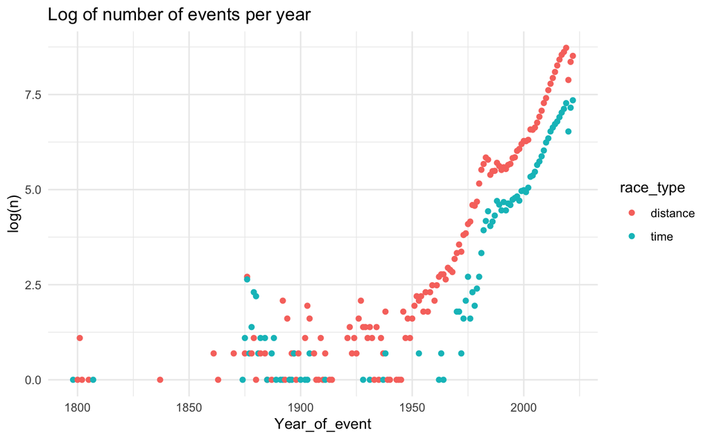

```r
data_clean %>%
    group_by(Year_of_event, race_type) %>%
    distinct(Event_name, race_type) %>%
    count(Year_of_event, race_type) %>%
    ggplot(aes(x = Year_of_event, y = log(n), colour = race_type)) +
    theme_minimal() +
    geom_point() +
    scale_y_continuous(labels = comma) +
    ggtitle('Log of number of events per year')
```

```r
data_clean_1950 <- data_clean %>% filter(Year_of_event >= 1950)
```

### 2.2 Athletes

```r
data_clean_1950 %>%
  group_by(Athlete_country) %>%
  summarise(athlete_count = length(unique(Athlete_ID)),
            total_finishers = n()) %>%
  add_row(Athlete_country = 'Total',
          athlete_count = sum(.$athlete_count),
          total_finishers = sum(.$total_finishers)) %>%
  mutate(avg_races = total_finishers/athlete_count) %>%
  arrange(desc(athlete_count)) %>%
  head(n = 10)
```

| Athlete_country | athlete_count | total_finishers | avg_races |
| --- | --- | --- | --- |
| Total | 1675698 | 7365349 | 4.395392 |
| USA | 288785 | 1385086 | 4.796253 |
| FRA | 246684 | 1150846 | 4.665264 |
| JPN | 138477 | 600522 | 4.336619 |
| RSA | 132664 | 875632 | 6.600374 |
| GBR | 97709 | 328052 | 3.357439 |
| GER | 76445 | 433014 | 5.664386 |
| CHN | 75114 | 219288 | 2.919403 |
| ESP | 72532 | 228347 | 3.148224 |
| ITA | 59475 | 341228 | 5.737335 |

After removing Athlete_ID 4033, Athlete 236 appears to have run the most number of ultramarathons in the world, totaling 801.

```r
data_clean_1950 %>%
  filter(Athlete_ID != 4033) %>%
  group_by(Athlete_ID) %>%
  summarise(race_count = n()) %>%
  arrange(desc(race_count)) %>%
  head(n = 10)
```

| Athlete_ID | race_count |
| --- | --- |
| 236 | 801 |
| 3977 | 636 |
| 10408 | 537 |
| 39253 | 507 |
| 24312 | 499 |
| 1046462 | 477 |
| 76721 | 472 |
| 67075 | 469 |
| 30526 | 468 |
| 43644 | 464 |

This runner completed their first ultramarathon in 2006 but has significantly increased his volume in the past few years, completing 118 in 2022, with almost all of the races taking place in TPE. The overwhelming majority of these races are under 50km, with 45km being the most frequent distance completed which is the shortest distance required to be recorded on the dataset.

```r
data_clean_1950 %>%
  filter(Athlete_ID == 236) %>%
  count(Year_of_event, race_location) %>%
  arrange(desc(Year_of_event))
```

| Year_of_event | race_location | n |
| --- | --- | --- |
| 2022 | TPE | 118 |
| 2021 | TPE | 102 |
| 2020 | TPE | 100 |
| 2019 | TPE | 84 |
| 2018 | TPE | 61 |
| 2017 | TPE | 72 |
| 2016 | TPE | 85 |
| 2015 | CHN | 1 |
| 2015 | TPE | 83 |
| 2014 | TPE | 26 |

[output cut: 9 more lines]

```r
data_clean_1950 %>%
  filter(Athlete_ID == 236) %>%
  mutate(race_distance = paste0(race_distance, race_unit)) %>%
  count(race_distance) %>%
  arrange(desc(n)) %>%
  head(n = 10)
```

| race_distance | n |
| --- | --- |
| 45km | 301 |
| 46km | 189 |
| 47km | 76 |
| 50km | 29 |
| 45.5km | 21 |
| 48km | 16 |
| 6h | 15 |
| 100km | 11 |
| 53km | 9 |
| 52km | 8 |

The fastest times for the most popular race distances saw a steady decline between the 1960’s to 1908’s as the popularity grew, and has seen a more gradual decline since. The two fastest times for 100 miles were in 2022 and 2021 by Aleksandr Sorokin, as well as the fastest 50km times being run in 2022. The 50m and 100km both saw their quickest times set in the 1990’s

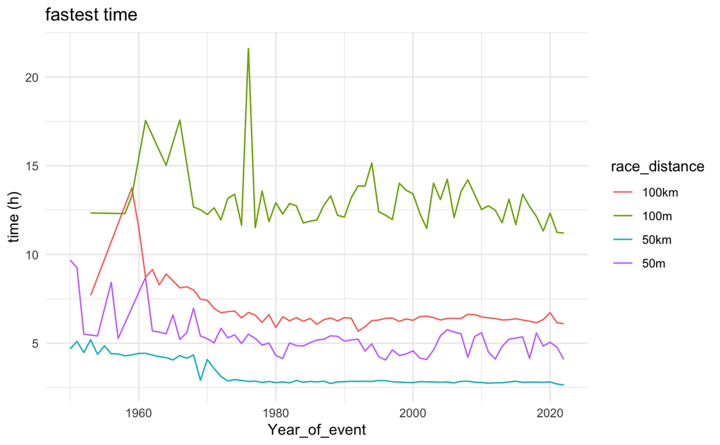

```r
data_clean_1950 %>%
  mutate(race_distance = paste0(race_distance, race_unit)) %>%
  filter(race_distance %in% c('50km','100km','50m','100m')) %>%
  group_by(Year_of_event, race_distance) %>%
  summarise(quickest_time = as.duration(min(athlete_duration)),
            average_time = mean(athlete_duration)) %>%
  ggplot(aes(x = Year_of_event, y = quickest_time/(60*60), colour = race_distance)) +
  geom_line() +
  theme_minimal() +
  ylab('time (h)') +
  ggtitle('fastest time') -> fast.time.p

plot(fast.time.p)
```

Although the fastest times have generally been trending quicker, the average times have been increasing since the 1980’s for 50km, 50m and 100m races, and increasing since the 1990’s for 100km. This is likely to be due to the increased participation rates; as a large range of people are setting themselves the challenge of completing an ultramarathon rather than just those who are setting out to win. It may also be due more people attempting increasingly challenging ultramarathons in terms of elevation and other conditions.

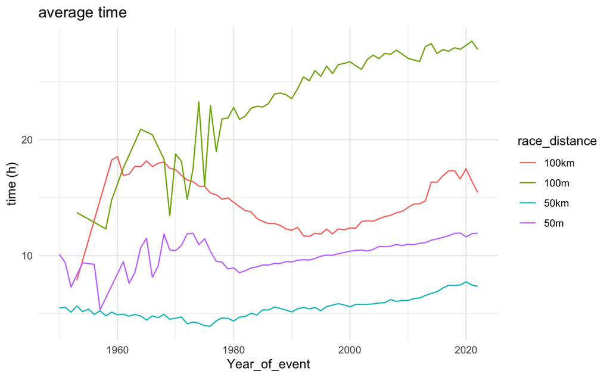

```r
data_clean_1950 %>%
  mutate(race_distance = paste0(race_distance, race_unit)) %>%
  filter(race_distance %in% c('50km','100km','50m','100m')) %>%
  group_by(Year_of_event, race_distance) %>%
  summarise(quickest_time = as.duration(min(athlete_duration)),
            average_time = mean(athlete_duration)) %>%
  ggplot(aes(x = Year_of_event, y = average_time/(60*60), colour = race_distance)) +
  geom_line() +
  theme_minimal() +
  ylab('time (h)') +
  ggtitle('average time') -> avg.time.p

plot(avg.time.p)
```

### 2.3 Gender

Anyone who’s been on the start line of a running race (ultramarathon or not) would be aware that the overwhelming majority of runners tend to be male. This is also apparent in this dataset with a little under 81% of runners identifying as male, 19% female with a negligible number of the entries being either ‘other’ or blank.

```r
data_clean_1950 %>%
  count(Athlete_gender) %>%
  mutate(proportion = percent(n/nrow(data_clean_1950), accuracy = 0.01))
```

| Athlete_gender | n | proportion |
| --- | --- | --- |
|  | 5 | 0.00% |
| F | 1405273 | 19.08% |
| M | 5960025 | 80.92% |
| X | 46 | 0.00% |

The good news is though that the trend is that this gap is decreasing, with the last few years seeing 23% of finishers being female globally. The chart below shows that there was a gradual increase in female runners during the 1960’s & 70’s, a bigger increase during the 80’s and 90’s with the trend slowing down since.

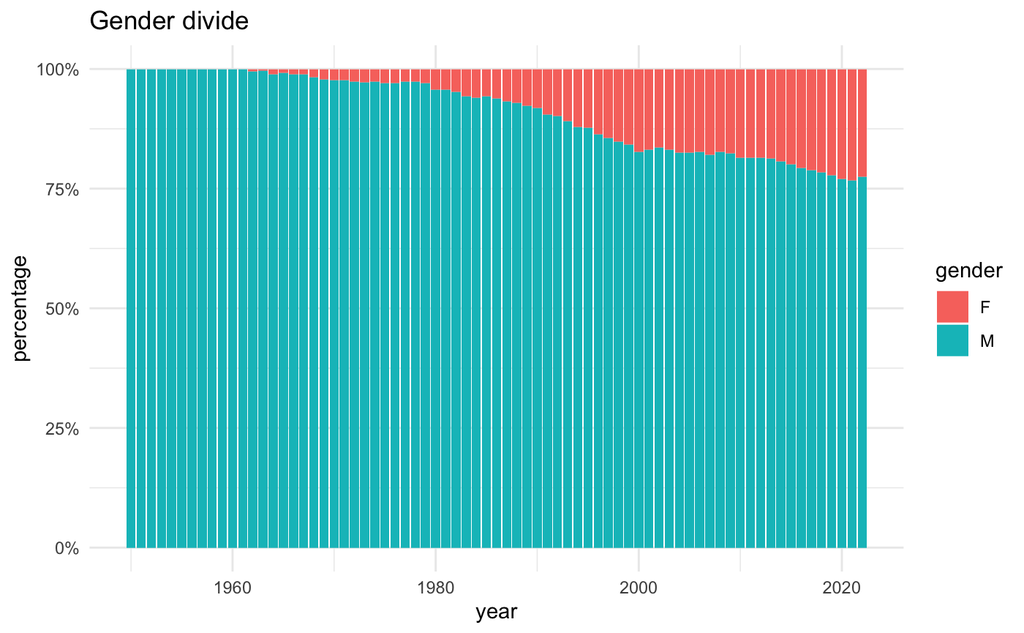

```r
data_clean_1950 %>%
  filter(Athlete_gender %in% c('M','F')) %>%
  count(Year_of_event, Athlete_gender) %>%
  group_by(Year_of_event) %>%
  mutate(percent = n/sum(n)) %>%
  ggplot(aes(x = Year_of_event, y = percent, fill = Athlete_gender)) +
  geom_bar(stat = 'identity') +
  theme_minimal() +
  labs(x = 'year', y = 'percentage', fill = 'gender') +
  ggtitle('Gender divide') +
  scale_y_continuous(labels = percent)
```

We can use the segmented package to split the regressions for each of these different regime changes. This suggests breaks of 1986 and 1998

```r
# Dataframe for percentage of female runners per year
female_perc <- data_clean_1950 %>%
  filter(Athlete_gender %in% c('M','F')) %>%
  count(Year_of_event, Athlete_gender) %>%
  group_by(Year_of_event) %>%
  mutate(percent = n/sum(n)) %>%
  filter(Athlete_gender == 'F')

# segment the linear model
lin.mod <- lm(percent ~ Year_of_event, data = female_perc)
seg.mod <- segmented::segmented(lin.mod, seg.Z = ~Year_of_event, psi = c(1980, 2000))

# Show the summary of the segmented model
summary(seg.mod)
```

```
    ***Regression Model with Segmented Relationship(s)***

Call:
segmented.lm(obj = lin.mod, seg.Z = ~Year_of_event, psi = c(1980,
    2000))

Estimated Break-Point(s):
                       Est. St.Err
psi1.Year_of_event 1986.33  0.712
psi2.Year_of_event 1998.40  0.812

Meaningful coefficients of the linear terms:
                   Estimate Std. Error t value Pr(>|t|)
(Intercept)      -4.4287631  0.3143296  -14.09   <2e-16 ***
Year_of_event     0.0022584  0.0001592   14.18   <2e-16 ***
U1.Year_of_event  0.0057377  0.0005058   11.34       NA
U2.Year_of_event -0.0049789  0.0005091   -9.78       NA
---
Signif. codes:  0 ‘***’ 0.001 ‘**’ 0.01 ‘*’ 0.05 ‘.’ 0.1 ‘ ’ 1

Residual standard error: 0.005741 on 55 degrees of freedom
Multiple R-Squared: 0.9947,  Adjusted R-squared: 0.9943

Boot restarting based on 6 samples. Last fit:
Convergence attained in 3 iterations (rel. change 1.0133e-12)
```

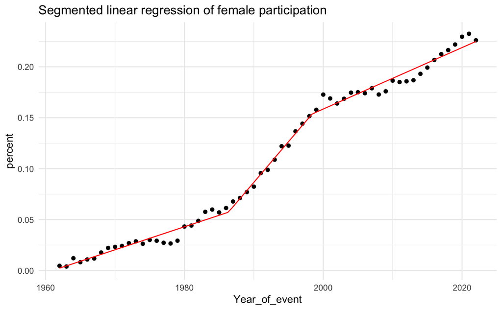

```r
newdata <- data.frame(Year_of_event = seq(min(female_perc$Year_of_event), max(female_perc$Year_of_event), length.out = 100))

# Generate predictions
newdata$pred <- predict(seg.mod, newdata = newdata)

# Plot the data and the regression line
ggplot(female_perc, aes(x = Year_of_event, y = percent)) +
  geom_point() +  # plot the data points
  geom_line(data = newdata, aes(y = pred), colour = 'red') +  # plot the regression line
  theme_minimal() +
  ggtitle('Segmented linear regression of female participation')
```

Although it’s good news that the percentage of females is increasing, the bad news is that it doesn’t look like it’ll get close to 50% any time soon based on current trends; as the chart below shows, extending the predicted changes until 2100.

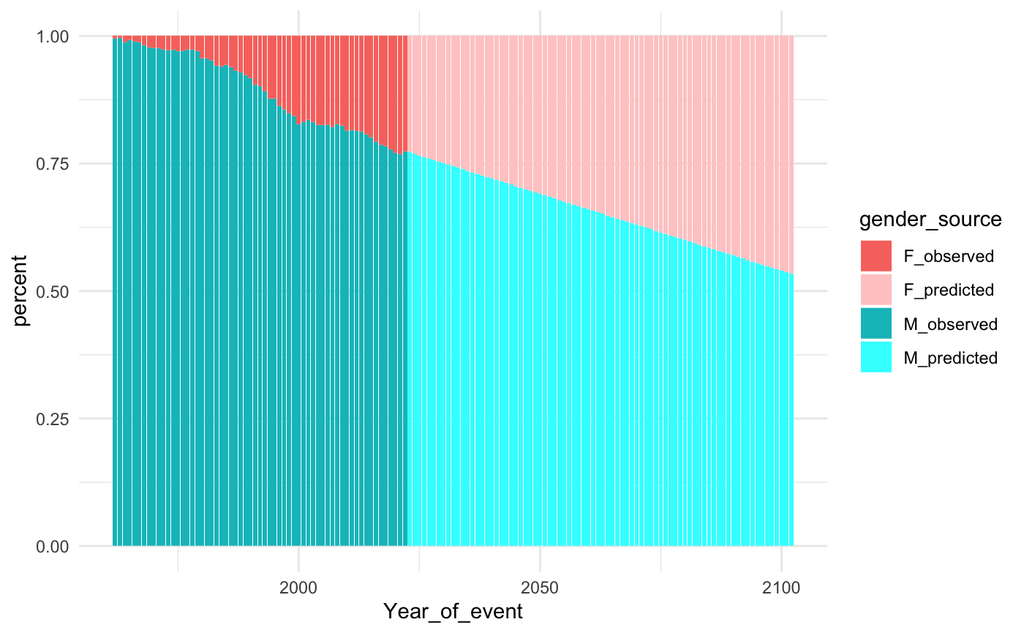

```r
# Extend dataframe with future years
future_years <- data.frame(Year_of_event = seq(max(female_perc$Year_of_event) + 1, max(female_perc$Year_of_event) + 80))

# Predict proportions for future years
future_years$percent <- predict(seg.mod, newdata = future_years, type = "response")
future_years$source <- 'predicted'

# Combine past data with future predictions
data_clean %>%
  filter(Year_of_event >= 1950,
         Athlete_gender %in% c('M','F')) %>%
  count(Year_of_event, Athlete_gender) %>%
  group_by(Year_of_event) %>%
  mutate(percent = n/sum(n)) %>%
  filter(Athlete_gender == 'F') %>%
  mutate(source = 'observed') %>%
  dplyr::select(Year_of_event, percent, source) %>%
  rbind(., future_years) %>%
  mutate(Male = 1-percent,
         Female = percent) %>%
  dplyr::select(-percent) %>%
  pivot_longer(cols = c('Male', 'Female'), names_to = 'Gender', values_to = 'percent') %>%
  mutate(gender_source = paste0(substr(Gender,1,1),'_', source)) %>%
  ggplot(aes(x = Year_of_event, y = percent, fill = gender_source)) +
  geom_bar(stat = "identity") +
  scale_fill_manual(values = c("F_observed" = "#F8766D", "M_observed" = "#00BFC4",
                               "F_predicted" = "#FFCCCC", "M_predicted" = "#33FFFF")) +
  theme_minimal()
```

```r
# highest & lowest female participation
data_clean_1950 %>%
  filter(Year_of_event >= 2017,
         Athlete_gender %in% c('M','F')) %>%
  group_by(Athlete_gender, race_location, Event_name) %>%
  summarise(n = n(), .groups = "drop") %>%
  group_by(race_location) %>%
  summarise(event_count = n_distinct(Event_name),
            female_percent = sum(if_else(Athlete_gender == 'F', n, 0)) / sum(n)) %>%
  ungroup() %>%
  filter(event_count > 1) %>%
  arrange(desc(female_percent)) %>%
  mutate(n = row_number(),
         female_percent = percent(female_percent, accuracy = 0.01)) %>%
  filter(n < 6 | n > (nrow(.) - 5)) %>%
  dplyr::select(-n)
```

| race_location | event_count | female_percent |
| --- | --- | --- |
| NZL | 99 | 35.26% |
| ISL | 23 | 33.91% |
| USA | 3936 | 33.43% |
| FIN | 123 | 33.26% |
| AUS | 508 | 32.96% |
| ESP | 420 | 11.04% |
| IND | 298 | 10.76% |
| AND | 12 | 10.01% |
| KOS | 4 | 9.57% |
| PAK | 4 | 2.59% |

A look at the major nations shows that the USA has been leading the pack for a while, with GBR in second. Races in Spain and France have a long way to go to catch up.

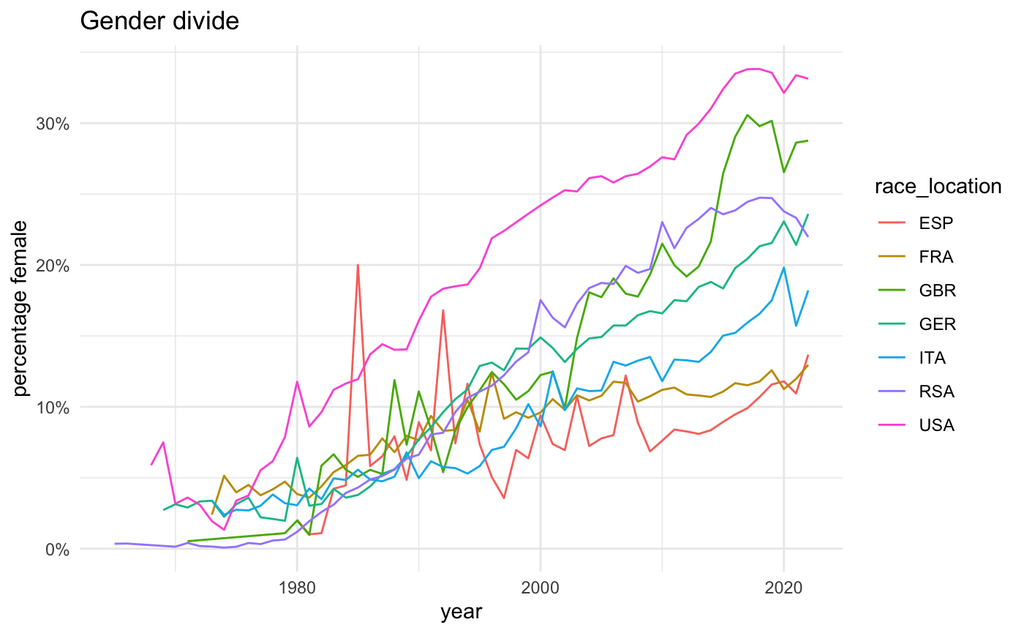

```r
data_clean_1950 %>%
  filter(Athlete_gender %in% c('M','F'),
         race_location %in% c('FRA','ESP','USA','GBR','GER','ITA','RSA')) %>%
  count(Year_of_event, Athlete_gender, race_location) %>%
  group_by(Year_of_event, race_location) %>%
  mutate(percent = n/sum(n)) %>%
  filter(Athlete_gender == 'F') %>%
  ggplot(aes(x = Year_of_event, y = percent, colour = race_location)) +
  geom_line() +
  theme_minimal() +
  labs(x = 'year', y = 'percentage female') +
  ggtitle('Gender divide') +
  scale_y_continuous(labels = percent)
```

One thing that is apparent is the gap between the fastest males and females is closing, with the average fastest male finishing time now around 22% faster than the female finish time for each of the major race distances. The average time of female finishers to males is also decreasing.

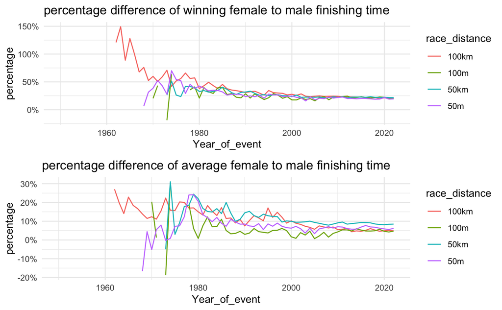

```r
gender_pace <- data_clean_1950 %>%
  mutate(race_distance = paste0(race_distance, race_unit),
         event = paste0(Year_of_event, '_', Event_name)) %>%
  filter(race_distance %in% c('50km','100km','50m','100m'),
         Athlete_gender %in% c('F','M')) %>%
  group_by(Year_of_event, race_distance, event, Athlete_gender) %>%
  summarise(fastest_time = min(athlete_duration),
            average_time = mean(athlete_duration)) %>%
  pivot_wider(names_from = Athlete_gender, values_from = c(fastest_time, average_time)) %>%
  mutate(fastest_diff = (fastest_time_F - fastest_time_M)/fastest_time_M,
         average_diff = (average_time_F - average_time_M)/average_time_M) %>%
  ungroup()

gender_pace %>%
  group_by(Year_of_event, race_distance) %>%
  summarise(fastest_diff = mean(fastest_diff, na.rm = TRUE),
            average_diff = mean(average_diff, na.rm = TRUE)) %>%
  ggplot(aes(x = Year_of_event, y = fastest_diff, colour = race_distance)) +
  geom_line() +
  theme_minimal() +
  ylab('percentage') +
  scale_y_continuous(labels = percent) +
  ggtitle('percentage difference of winning female to male finishing time') -> fast.female.p

gender_pace %>%
  group_by(Year_of_event, race_distance) %>%
  summarise(fastest_diff = mean(fastest_diff, na.rm = TRUE),
            average_diff = mean(average_diff, na.rm = TRUE)) %>%
  ggplot(aes(x = Year_of_event, y = average_diff, colour = race_distance)) +
  geom_line() +
  theme_minimal() +
  ylab('percentage') +
  scale_y_continuous(labels = percent) +
  ggtitle('percentage difference of average female to male finishing time') -> avg.female.p

grid.arrange(fast.female.p, avg.female.p, ncol = 1)
```

There is also a growing percentage of races that are being won outright by female runners, seeing 7.6% of female winners in 2022.

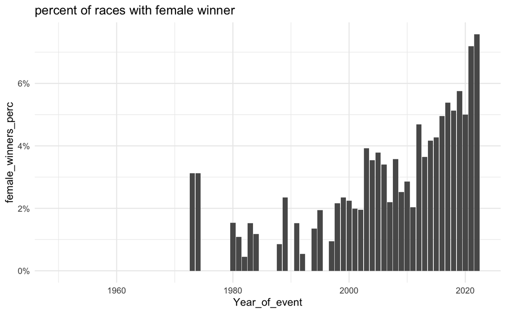

```r
gender_pace %>%
  mutate(female_winner = if_else(fastest_time_F < fastest_time_M,1,0)) %>%
  group_by(Year_of_event) %>%
  summarise(female_winners = sum(female_winner, na.rm = TRUE),
            female_winners_perc = female_winners/n()) %>%
  ggplot(aes(x = Year_of_event, y = female_winners_perc)) +
  geom_bar(stat = 'identity') +
  theme_minimal() +
  scale_y_continuous(labels = percent) +
  ggtitle('percent of races with female winner')
```

### 2.4 Age

Along with the increased participation of female athletes, the age ranges of athletes has also diversified. As mentioned previously, the age categories differ based on race location, so the chart below just slices the ages into 5 year buckets. The increase in participants over 30 has progressively increased since the 60’s, together with a decline in runners below 25, with runners under 20 almost vanishing; falling from a high of 18% in the 1960’s to under 0.5% for the past few years.

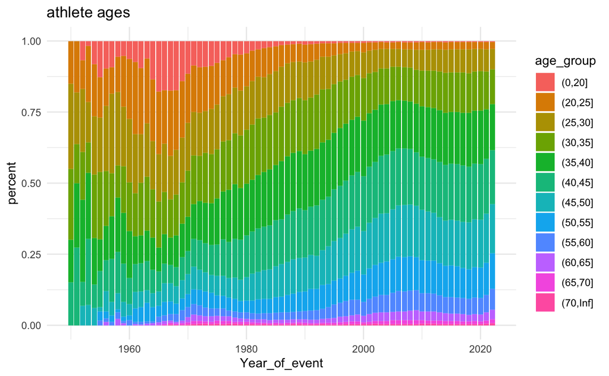

```r
age_groups = data.frame(age_breaks = c(0,seq.int(20,70, by = 5), Inf))

data_clean_1950 %>%
  mutate(age_group = cut(athlete_age, age_groups$age_breaks)) %>%
  count(Year_of_event, age_group) %>%
  filter(complete.cases(.)) %>%
  ungroup() %>% group_by(Year_of_event) %>%
  mutate(percent = n/sum(n)) %>%
  ggplot(aes(x = Year_of_event, y = percent, fill = age_group)) +
  geom_bar(stat = 'identity') +
  theme_minimal() +
  ggtitle('athlete ages')
```

### 2.5 Nationality

```r
data_clean_1950 %>%
  filter(race_location %in% race_locations) %>%
  group_by(Year_of_event, race_location) %>%
  distinct(Athlete_country) %>%
  count(Year_of_event, race_location) %>%
  ggplot(aes(x = Year_of_event, y = n, colour = race_location)) +
  theme_minimal() +
  geom_point() +
  ggtitle('participant nationalities per race location')
```

[output not shown]

A look at the last set of races before Covid sees Comrades as the race with the greatest number of nationalities present, followed by the UTMB group of races.

```r
data_clean_1950 %>%
  filter(Year_of_event == 2019) %>%
  group_by(Year_of_event, Event_name, race_location) %>%
  distinct(Athlete_country) %>%
  count(Year_of_event, Event_name, race_location) %>%
  arrange(desc(n)) %>% head(n = 20)
```

| Year_of_event | Event_name | race_location | n |
| --- | --- | --- | --- |
| 2019 | Comrades Marathon - Up Run (RSA) | RSA | 72 |
| 2019 | Courmayeur-Champex-Chamonix (CCC) (ITA) | ITA | 72 |
| 2019 | Orsières-Champex-Chamonix (OCC) (SUI) | SUI | 63 |
| 2019 | Sur les Traces des Ducs de Savoie (TDS) (ITA) | ITA | 63 |
| 2019 | Ultra Trail Tour du Mont Blanc (UTMB) (FRA) | FRA | 63 |
| 2019 | Cortina Trail (ITA) | ITA | 62 |
| 2019 | Two Oceans Marathon (RSA) | RSA | 61 |
| 2019 | Two Oceans Marathon - 50km Split (RSA) | RSA | 61 |
| 2019 | Lavaredo Ultra Trail (ITA) | ITA | 56 |
| 2019 | Cappadocia 119 km Ultra-Trail (TUR) | TUR | 53 |

[output cut: 10 more lines]

```r
data_clean_1950 %>%
  filter(Event_name %in% c('Comrades Marathon - Down Run (RSA)','Comrades Marathon - Up Run (RSA)'),
         Year_of_event != 2022) %>%
  mutate(foreign_race = if_else(Athlete_country == race_location, 0, 1)) %>%
  group_by(Year_of_event, Event_name) %>%
  summarise(foreign_participation = sum(foreign_race)/n()) %>%
  ggplot(aes(x = Year_of_event, y = foreign_participation, colour = Event_name)) +
  theme_minimal() +
  geom_point() +
  ggtitle('foreign participation per Comrades race') +
  scale_y_continuous(labels = percent) +
  theme(legend.position="bottom", legend.direction="vertical")
```

[output not shown]

## 3 Conclusion

It’s clear to see from the analysis presented that the popularity of ultra-marathon running continues to increase substantially each year, both in terms of the number of participants and number of events available to take part in. The diverstity element is also improving, based on the data available, for gender, age and range of nationalities. The gender differences are steadily improving but has a long way to go to becoming more equal in terms of male/female ratio, and some countries such as Spain and France are a long way behind USA and UK.

Data not available in this dataset is ethnicity of participant, which has an even larger disparity than gender. The University of Lancaster [conducted a survey](https://static1.squarespace.com/static/617668ef2b69d5286e7fad19/t/63dbb7697374b920b8413c70/1675343728326/Trail+Ultra+Survey+Report.pdf) in 2022, consisting of over 1,000 respondants, of which 95% indicated their ethnicity as “White”. Further analysis would be interesting to see whether or not this is a percentage that has changed at all over recent years